# Results

The six cancers shown are the top six cancers affecting individuals in Multnomah County.

In our research, we analyzed the age groups with a rate of cancer per 100,000 people above 50. Moving forward, this includes the 55-64, 65-74, 75-84, and over 85 years old age ranges.

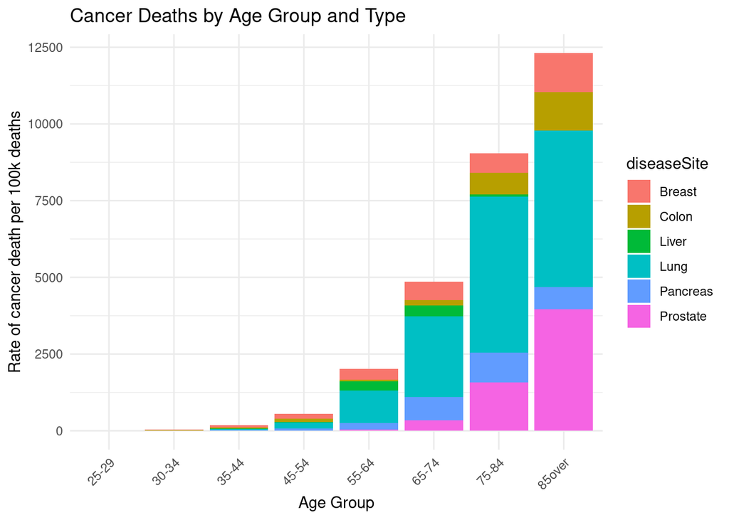

A bar chart that represents the top 6 cancers causing death by age group in Multnomah County from 2014-2023.

```r
# Summarize total cases per age group and cancer type
cancer_summary <- filtered_cancer_rates %>%
  group_by(ageRanges, diseaseSite) %>%
  summarize(totalRate = sum(rate_per_100k, na.rm = TRUE))

# Plot
ggplot(cancer_summary, aes(x = ageRanges, y = totalRate, fill = diseaseSite)) +
  geom_bar(stat = "identity") +
  labs(title = "Cancer Deaths by Age Group and Type",
       x = "Age Group", y = "Rate of cancer death per 100k deaths") +
  theme_minimal() +
  theme(axis.text.x = element_text(angle = 45, hjust = 1))
```

**Cancers with high mortality rates by sex**

**Somatic cancers with high mortality rates**

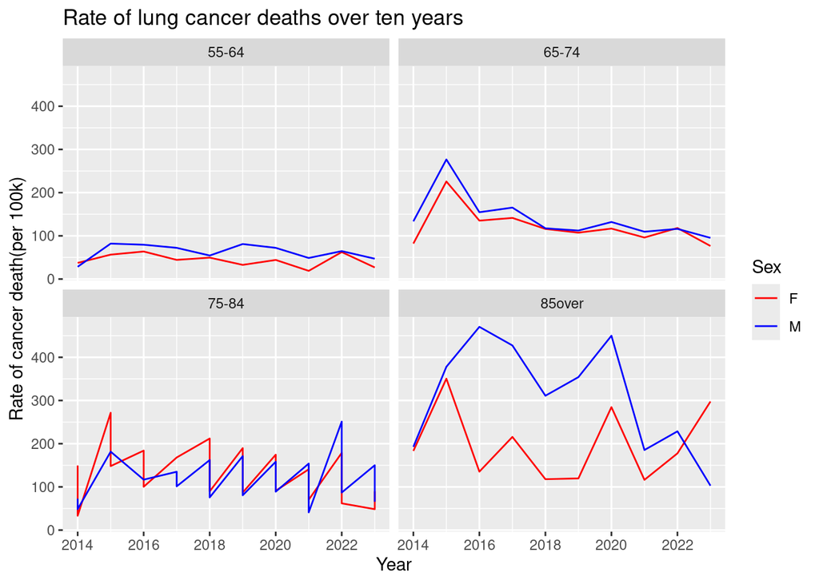

A line plot that visualizes lung cancer fatality rates in Multnomah County 2014-2023. There are statistically significant differences of lung cancer mortality rate in years and age ranges, but not for sex.

```r
lungCancer <- filtered_cancer_rates %>%
  filter(diseaseSite=="Lung")%>%
  filter(ageRanges %in% c("55-64", "65-74", "75-84", "85over"))

ggplot(lungCancer, mapping = aes(x = ddodyear, y = rate_per_100k, color = ddsex)) +
  geom_line(aes(group = interaction(ddsex, diseaseSite)))+
  facet_wrap(~ageRanges)+
  labs(title = "Rate of lung cancer deaths over ten years",
       color = "Sex",
       x = "Year",
       y = "Rate of cancer death(per 100k)")+
    scale_color_manual(labels = c("F", "M"), values = c("red", "blue"))
```

An ANOVA test suggests that there is a statistically significant difference in the lung cancer death rates among different age ranges and years. The test also suggests there is no statistically significant difference in lung cancer death rates among sex.

A Tukey’s post-hoc test suggests the statistically significant age groups depicted above are as follows:

- A: 55-64 years old.
- B: 65-74 and 75-84 years old.
- C: Over 85 years old.

The statistically significantly different years can be categorized into groups as follows:

| A | AB | B |
| --- | --- | --- |
| 2014 | 2016 | 2015 |
| 2021 | 2017 |  |
| 2023 | 2018 |  |
|  | 2019 |  |
|  | 2020 |  |
|  | 2022 |  |

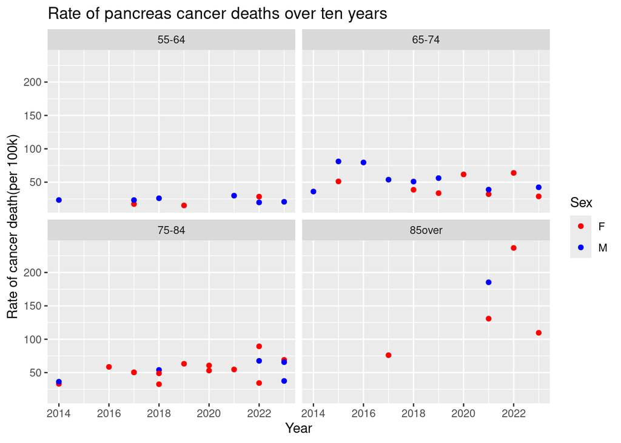

```r
pancreasCancer <- filtered_cancer_rates %>%
  filter(diseaseSite=="Pancreas")%>%
  filter(ageRanges %in% c("55-64", "65-74", "75-84", "85over"))

ggplot(pancreasCancer, mapping = aes(x = ddodyear, y = rate_per_100k, color = ddsex)) +
  geom_point(aes(group = interaction(ddsex, diseaseSite)))+
  facet_wrap(~ageRanges)+
  labs(title = "Rate of pancreas cancer deaths over ten years",
       color = "Sex",
       x = "Year",
       y = "Rate of cancer death(per 100k)")+
    scale_color_manual(labels = c("F", "M"), values = c("red", "blue"))
```

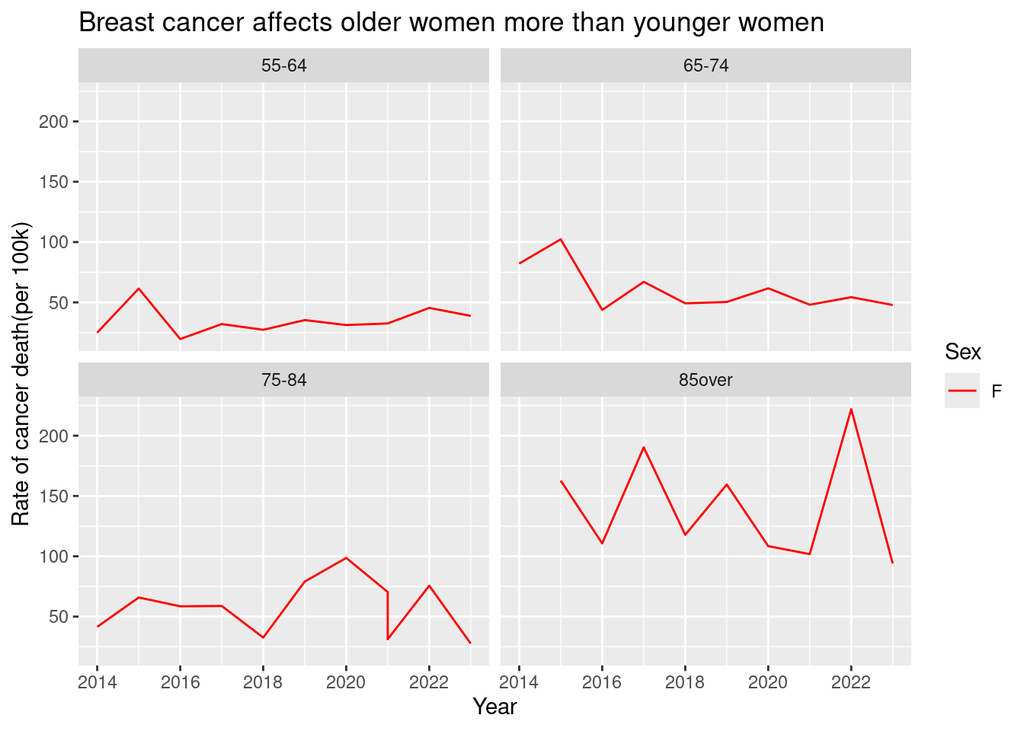

A line plot that visualizes breast cancer fatality rates in Multnomah County 2014-2023. There are statistically significant differences of breast cancer mortality rate in years and age ranges.

```r
breastCancer <- filtered_cancer_rates %>%
  filter(diseaseSite=="Breast")%>%
  filter(ageRanges %in% c("55-64", "65-74", "75-84", "85over"))

ggplot(breastCancer, mapping = aes(x = ddodyear, y = rate_per_100k, color = ddsex)) +
  geom_line(aes(group = interaction(ddsex, diseaseSite)))+
  facet_wrap(~ageRanges)+
  labs(title = "Breast cancer affects older women more than younger women",
      color = "Sex",
       x = "Year",
       y = "Rate of cancer death(per 100k)") +
  scale_color_manual(labels = c("F"), values = c("red"))
```

An ANOVA test suggests that there is a statistically significant difference in the breast cancer death rates among different age ranges. The test also suggests there is a statistically significant difference in breast cancer death rates across the ten year timespan.

A Tukey’s post-hoc test suggests the statistically significant age groups depicted above are as follows:

- A: 55-64 and 65-74 years old.
- B: 75-84 years old.
- C: Over 85 years old.

The Tukey test does not suggest any significant differences in the years in pairwise comparisons. This indicates that there may be smaller variations of breast cancer rates over the ten year timespan.

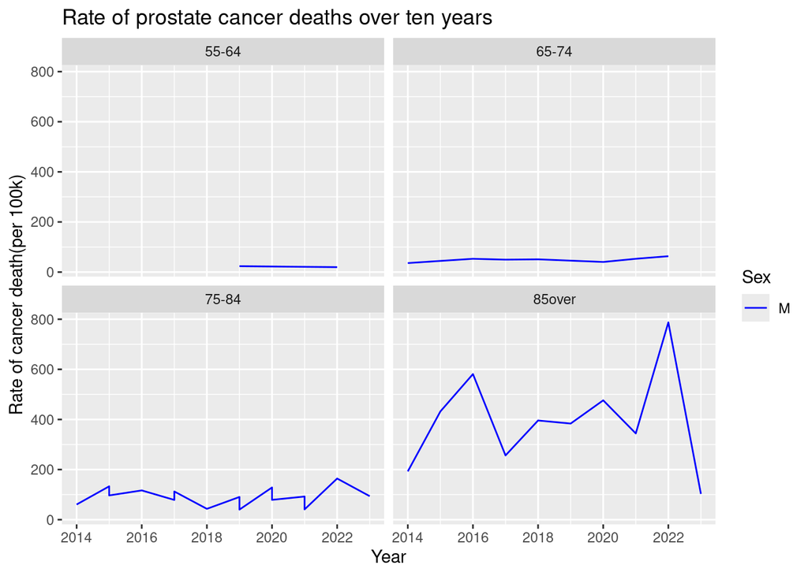

A line plot that visualizes prostate cancer fatality rates in Multnomah County 2014-2023. There are statistically significant differences of prostate cancer mortality rate in age ranges, but not for years of data collection.

```r
prostateCancer <- filtered_cancer_rates %>%
  filter(diseaseSite=="Prostate")%>%
  filter(ageRanges %in% c("55-64", "65-74", "75-84", "85over"))

ggplot(prostateCancer, mapping = aes(x = ddodyear, y = rate_per_100k, color = ddsex)) +
  geom_line(aes(group = interaction(ddsex, diseaseSite)))+
  facet_wrap(~ageRanges)+
  labs(title = "Rate of prostate cancer deaths over ten years",
       color = "Sex",
       x = "Year",
       y = "Rate of cancer death(per 100k)")+
  scale_color_manual(labels = c("M"), values = c("blue"))
```

An ANOVA test suggests that there is a statistically significant difference in the prostate cancer death rates among different age ranges. The test also suggests there is no statistically significant difference in prostate cancer death rates across the ten year timespan.

A Tukey’s post-hoc test suggests the statistically significant age groups depicted above are as follows:

- A: 55-64, 65-74, and 75-84 years old.
- B: Over 85 years old.

An ANOVA test reveals that there is no statistically significant difference between pancreas cancer rates among sex or in year.

A Tukey’s post-hoc test reveals that the statistically significant age groups depicted above are as follows:

- A: 55-64 years old.
- B: 65-74 and 75-84 years old.
- C: Over 85 years old.

**Rates of cancer with age**

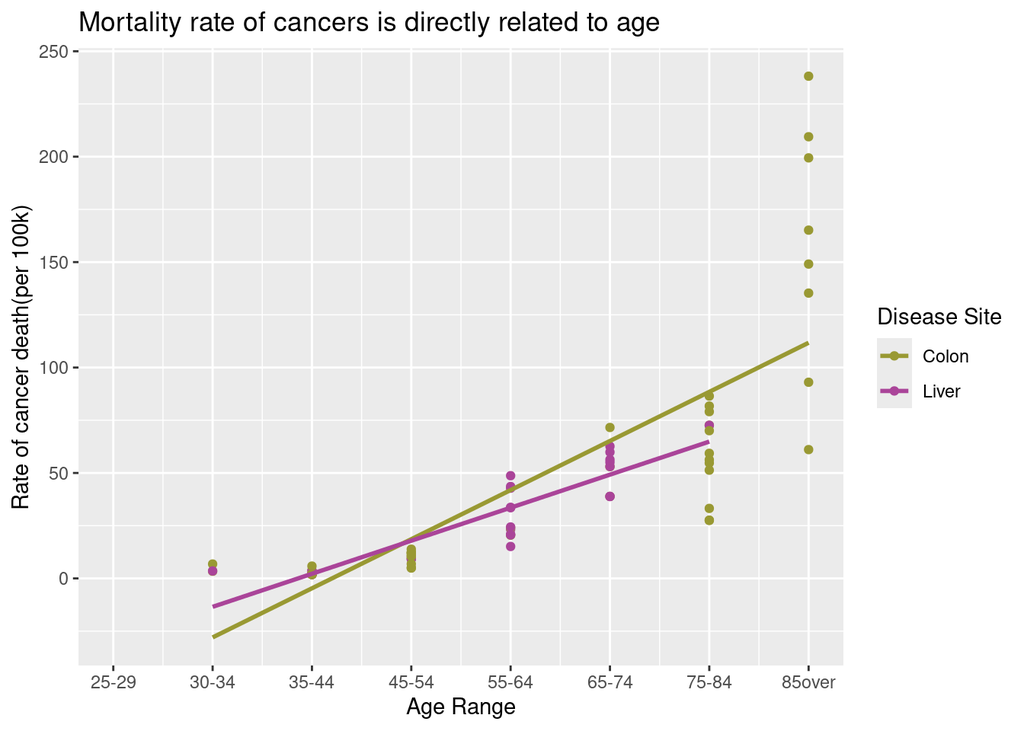

A line plot that shows the correlation between the average rate of cancer for each age range

```r
group_cancer<-filtered_cancer_rates %>%
  filter(diseaseSite == "Colon" | diseaseSite == "Liver")

age_levels <- c("0-5", "6-9", "10-14", "15-17", "18-19",
                "20-24", "25-29", "30-34", "35-44", "45-54",
                "55-64", "65-74", "75-84", "85over")


group_cancer$ageRanges <- as.numeric(factor(group_cancer$ageRanges, levels = age_levels))

ggplot(group_cancer, aes(x = ageRanges, y = rate_per_100k, color = diseaseSite)) +
  geom_point() +
  geom_smooth(method = lm, se = FALSE) +
  scale_x_continuous(breaks = 1:length(age_levels), labels = age_levels) +
  labs(x = "Age Range",
       color = "Disease Site",
       title = "Mortality rate of cancers is directly related to age",
       y= "Rate of cancer death(per 100k)",
)+
     scale_color_manual(labels = c("Colon", "Liver"), values = c("#999933", "#AA4499"))
```

Based on a Pearson’s correlation coefficient, there is a strong correlation between average rates of cancer and age. For colon cancer, the average rate of cancer and age has a correlation of 0.80. The correltation coefficient for the average liver cancer rate and age is 0.89.